# STAT115 Homework 1 By MACAULAY

Friday June 16, 2023

# Part I: Introduction to R

## Problem 1: Installation

**Please install the following R/Bioconductor packages**

```r
if (!requireNamespace("BiocManager", quietly = TRUE))
    install.packages("BiocManager")
BiocManager::install()
BiocManager::install("sva")

install.packages(c("ggplot2", "dplyr", "tidyr", "HistData", "mvtnorm",
                   "reticulate"))
```

Please run this command (use `eval=TRUE`) to see if Bioconductor can work fine.

```r
BiocManager::valid()
```

```r
# these packages are needed for HW2
# affy and affyPLM are needed to read the microarray data and run RMA
#library(sva) # for batch effect correction. Contains ComBat and sva.
library(ggplot2) # for plotting
library(dplyr) # for data manipulation
library(reticulate) # needed to run python in Rstudio
# these next two are not essential to this course
library(mvtnorm) # need this to simulate data from multivariate normal
library(HistData) # need this for data
```

## Problem 2: Getting help

You can use the `mean()` function to compute the mean of a vector like so:

```r
x1 <- c(1:10, 50)
mean(x1)
```

```
## [1] 9.545455
```

```r
x1
```

```
##  [1]  1  2  3  4  5  6  7  8  9 10 50
```

However, this does not work if the vector contains NAs:

```r
x1_na <- c(1:10, 50, NA)
mean(x1_na)
```

```
## [1] NA
```

**Please use R documentation to find the mean after excluding NA’s (hint: `?mean`)**

```r
# your code here
mean(x1_na, na.rm = TRUE)
```

```
## [1] 9.545455
```

Grading: Grade on correctness.

- 0.5pt

# Part II: Data Manipulation

## Problem 3: Basic Selection

In this question, we will practice data manipulation using a dataset collected by Francis Galton in 1886 on the heights of parents and their children. This is a very famous dataset, and Galton used it to come up with regression and correlation.

The data is available as `GaltonFamilies` in the `HistData` package. Here, we load the data and show the first few rows. To find out more information about the dataset, use `?GaltonFamilies`.

```r
#install.packages("HistData")
library(HistData)
data(GaltonFamilies)
head(GaltonFamilies)
```

```
##   family father mother midparentHeight children childNum gender childHeight
## 1    001   78.5   67.0           75.43        4        1   male        73.2
## 2    001   78.5   67.0           75.43        4        2 female        69.2
## 3    001   78.5   67.0           75.43        4        3 female        69.0
## 4    001   78.5   67.0           75.43        4        4 female        69.0
## 5    002   75.5   66.5           73.66        4        1   male        73.5
## 6    002   75.5   66.5           73.66        4        2   male        72.5
```

1. **Please report the height of the 10th child in the dataset.**

```r
# your code here
(tenth_child_height <- GaltonFamilies$childHeight[10])
```

```
## [1] 68
```

```r
#tenth_child_height
```

2. **What is the breakdown of male and female children in the dataset?**

```r
# your code here
(breakdown <- summary(GaltonFamilies$gender))
```

```
## female   male
##    453    481
```

3. **How many observations (number of rows) are in Galton’s dataset? Please answer this question without consulting the R help.**

```r
(observations <- nrow(GaltonFamilies))
```

```
## [1] 934
```

```r
# your code here
```

4. **What is the mean height for the 1st child in each family?**

```r
# your code here
first_childs <- subset(GaltonFamilies, childNum == 1)
(mean_height <- mean(first_childs$childHeight))
```

```
## [1] 69.82098
```

5. **Create a table showing the mean height for male and female children.**

```r
# your code here
(mean_gener_height <- aggregate(childHeight ~ gender, data = GaltonFamilies, FUN = mean))
```

```
##   gender childHeight
## 1 female    64.10397
## 2   male    69.23410
```

6. **What was the average number of children each family had?**

```r
# your code here
(average_childrennum_family <- aggregate(children ~ family, data = GaltonFamilies, FUN = function(x) mean(x[1])))
```

```
##     family children
## 1      001        4
## 2      002        4
## 3      003        2
## 4      004        5
## 5      005        6
## 6      006        1
## 7      007        6
## 8      008        3
## 9      009        1
## 10     010        1
## 11     011        8
## 12     012        1
## 13     013        2
## 14     014        2
```

[output cut: 191 more lines]

7. **Convert the children’s heights from inches to centimeters and store it in a column called `childHeight_cm` in the `GaltonFamilies` dataset. Show the first few rows of this dataset.**

```r
# your code here
GaltonFamilies$childHeight_cm <- GaltonFamilies$childHeight * 2.54
head(GaltonFamilies)
```

```
##   family father mother midparentHeight children childNum gender childHeight
## 1    001   78.5   67.0           75.43        4        1   male        73.2
## 2    001   78.5   67.0           75.43        4        2 female        69.2
## 3    001   78.5   67.0           75.43        4        3 female        69.0
## 4    001   78.5   67.0           75.43        4        4 female        69.0
## 5    002   75.5   66.5           73.66        4        1   male        73.5
## 6    002   75.5   66.5           73.66        4        2   male        72.5
##   childHeight_cm
## 1        185.928
## 2        175.768
## 3        175.260
## 4        175.260
## 5        186.690
## 6        184.150
```

## Problem 4: Spurious Correlation

```r
# set seed for reproducibility
set.seed(1234)
N <- 25
ngroups <- 100000
sim_data <- data.frame(group = rep(1:ngroups, each = N),
                       X = rnorm(N * ngroups),
                       Y = rnorm(N * ngroups))
head(sim_data)
```

```
##   group          X           Y
## 1     1 -1.2070657 -0.01702494
## 2     1  0.2774292  0.40812082
## 3     1  1.0844412 -1.56429132
## 4     1 -2.3456977  1.13073145
## 5     1  0.4291247  0.82286009
## 6     1  0.5060559 -1.95833239
```

In the code above, we generate 10^{5} groups of 25 observations each. In each group, we have X and Y, where X and Y are independent normally distributed data and have 0 correlation.

1. **Find the correlation between X and Y for each group, and display the highest correlations.**

Hint: since the data is quite large and your code might take a few moments to run, you can test your code on a subset of the data first (e.g. you can take the first 100 groups like so):

```r
sim_data_first_100 <- sim_data[1:100, ]
sim_data_first_100$correlation <- by(sim_data_first_100, sim_data_first_100$group, FUN = function(x) cor(x$X, x$Y))
head(sim_data_first_100[order(sim_data_first_100$correlation, decreasing = TRUE), ])
```

```
##    group          X          Y correlation
## 4      1 -2.3456977  1.1307314  0.04792116
## 8      1 -0.5466319  0.8969592  0.04792116
## 12     1 -0.9983864  0.9420667  0.04792116
## 16     1 -0.1102855 -1.5405679  0.04792116
## 20     1  2.4158352  0.9731538  0.04792116
## 24     1  0.4595894  0.2673287  0.04792116
```

In general, this is good practice whenever you have a large dataset: If you are writing new code and it takes a while to run on the whole dataset, get it to work on a subset first. By running on a subset, you can iterate faster.

However, please do run your final code on the whole dataset.

```r
# your code here
sim_data$correlation <- by(sim_data, sim_data$group, FUN = function(x) cor(x$X, x$Y))
head(sim_data[order(sim_data$correlation, decreasing = TRUE), ])
```

```
##        group          X          Y correlation
## 99655   3987  0.8891285 -1.2684142   0.8014245
## 199655  7987 -0.8480355 -1.0288452   0.8014245
## 299655 11987 -1.0732217  0.5216807   0.8014245
## 399655 15987 -0.1682145 -0.2705579   0.8014245
## 499655 19987 -1.7055112 -0.5573700   0.8014245
## 599655 23987  0.5994902  0.9540217   0.8014245
```

2. **The highest correlation is around 0.8. Can you explain why we see such a high correlation when X and Y are supposed to be independent and thus uncorrelated?**

```r
head(sim_data)
```

[output not shown]

# Part III: Plotting

## Problem 5

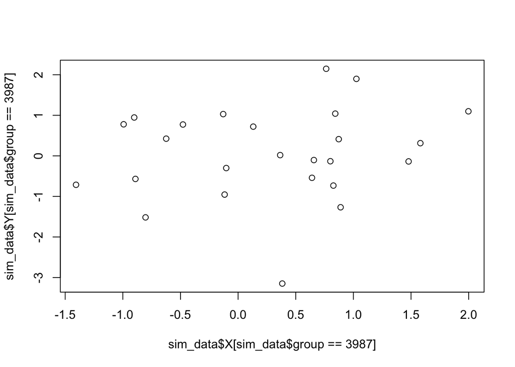

```r
# your code here
plot(sim_data$X[sim_data$group == 3987], sim_data$Y[sim_data$group == 3987])
```

Grading: 1pt.

## Problem 6

We generate some sample data below. The data is numeric, and has 3 columns: X, Y, Z.

```r
library(MASS)
N <- 100
Sigma <- matrix(c(1, 0.75, 0.75, 1), nrow = 2, ncol = 2) * 1.5
means <- list(c(11, 3), c(9, 5), c(7, 7), c(5, 9), c(3, 11))
dat <- lapply(means, function(mu)
  rmvnorm(N, mu, Sigma))
dat <- as.data.frame(Reduce(rbind, dat)) %>%
  mutate(Z = as.character(rep(seq_along(means), each = N)))
names(dat) <- c("X", "Y", "Z")
```

1. **Compute the overall correlation between X and Y.**

```r
# your code here
(correlation <- cor(dat$X, dat$Y))
```

```
## [1] -0.7362015
```

2. **Make a plot showing the relationship between X and Y. Comment on the correlation that you see.**

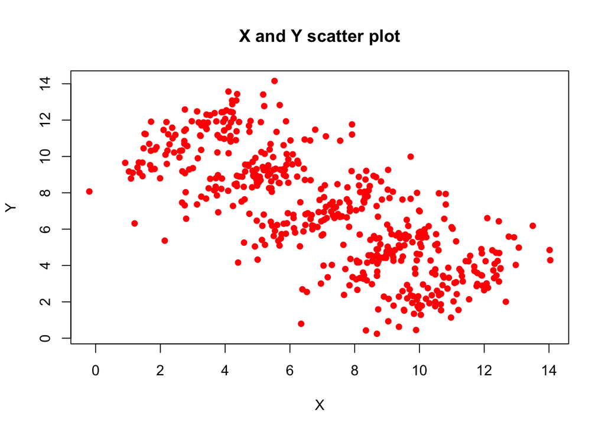

```r
# your code here
plot(dat$X, dat$Y, col = "red", xlab = "X", ylab = "Y",pch = 16, main = "X and Y scatter plot")
```

Your text answer here. The correlation between X and Y is negative, meaning that as the values of X increases, the values of Y tend to decrease, and vice versa. The correlation between X and Y is negative.

3. **Compute the correlations between X and Y for each level of Z.**

```r
# your code here
(each_z_correlation <- by(dat, dat$Z, function(subset) cor(subset$X, subset$Y)))
```

```
## dat$Z: 1
## [1] 0.7431233
## ------------------------------------------------------------
## dat$Z: 2
## [1] 0.7562614
## ------------------------------------------------------------
## dat$Z: 3
## [1] 0.77199
## ------------------------------------------------------------
## dat$Z: 4
## [1] 0.784718
## ------------------------------------------------------------
## dat$Z: 5
## [1] 0.7298214
```

4. **Make a plot showing the relationship between X and Y, but this time, color the points using the value of Z. Comment on the result, especially any differences between this plot and the previous plot.**

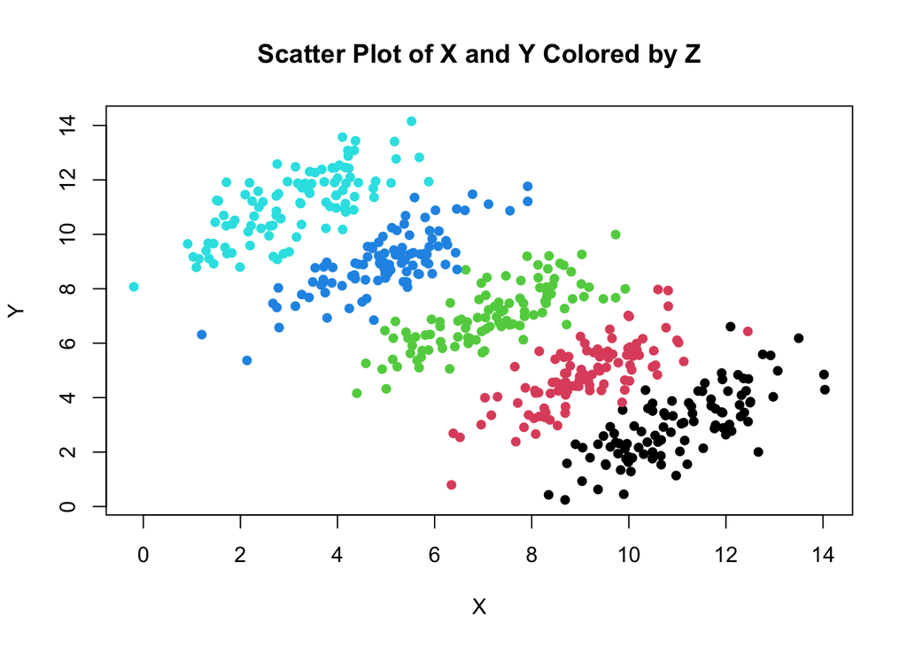

```r
# your code here
plot(dat$X, dat$Y,  col = dat$Z, xlab = "X", ylab = "Y", pch = 16, main = "Scatter Plot of X and Y Colored by Z")
```

Your text answer here. For each level of Z, there is a positive correlation between X and Y, while the previous graph showed an overall negative correlation between X and Y